# R Notebook

```r
library(xts)
library(forecast)
library(urca)
library(ggplot2)
library(ggfortify)
```

## ts object

```r
ts_sample <- ts(1:36,start = c(2000,1),freq=12)
ts_sample
```

```
     Jan Feb Mar Apr May Jun Jul Aug Sep Oct Nov Dec
2000   1   2   3   4   5   6   7   8   9  10  11  12
2001  13  14  15  16  17  18  19  20  21  22  23  24
2002  25  26  27  28  29  30  31  32  33  34  35  36
```

```r
ts_freq4 <- ts(1:8,start=c(2000,1),freq=4)
ts_freq4
```

```
     Qtr1 Qtr2 Qtr3 Qtr4
2000    1    2    3    4
2001    5    6    7    8
```

```r
mat_with_name =matrix(1:8,
                      ncol=4,
                      dimnames = list(c("row1","row2"),c("col1","col2","col3","col4")))
mat_with_name
```

```
     col1 col2 col3 col4
row1    1    3    5    7
row2    2    4    6    8
```

```r
ts(mat_with_name,start=c(2000,1),freq=12)
```

```
         col1 col2 col3 col4
Jan 2000    1    3    5    7
Feb 2000    2    4    6    8
```

```r
window(ts_freq4,start=c(2000,2),end=c(2001,1))
```

```
     Qtr1 Qtr2 Qtr3 Qtr4
2000         2    3    4
2001    5
```

```r
print(head(Seatbelts))
```

```
         DriversKilled drivers front rear   kms PetrolPrice VanKilled law
Jan 1969           107    1687   867  269  9059   0.1029718        12   0
Feb 1969            97    1508   825  265  7685   0.1023630         6   0
Mar 1969           102    1507   806  319  9963   0.1020625        12   0
Apr 1969            87    1385   814  407 10955   0.1008733         8   0
May 1969           119    1632   991  454 11823   0.1010197        10   0
Jun 1969           106    1511   945  427 12391   0.1005812        13   0
```

```r
print(tail(Seatbelts))
```

```
         DriversKilled drivers front rear   kms PetrolPrice VanKilled law
Jul 1984            79    1222   601  472 21486   0.1149360         7   1
Aug 1984            96    1284   644  521 21626   0.1147970         5   1
Sep 1984           122    1444   643  429 20195   0.1140932         7   1
Oct 1984           120    1575   641  408 19928   0.1164655         7   1
Nov 1984           137    1737   711  490 18564   0.1160261         4   1
Dec 1984           154    1763   721  491 18149   0.1160667         7   1
```

```r
print(class(Seatbelts))
```

```
[1] "mts" "ts"
```

```r
?Seatbelts
```

```r
subset(Seatbelts[,"front"],month=3)
```

```
Time Series:
Start = 1969.167
End = 1984.167
Frequency = 1
 [1]  806 1006  840  879  787  724  777  671  616  808  794  720  688  660  475  513
```

## xts object

```r
xts_sample <- as.xts(matrix(1:5,
                     dimnames=list(c("2000-01-01","2000-01-02","2000-01-03","2000-01-04","2000-01-05"))),
                     ncol=1)
xts_sample
```

```
           [,1]
2000-01-01    1
2000-01-02    2
2000-01-03    3
2000-01-04    4
2000-01-05    5
```

```r
print(xts_sample['2000-01-02'])
```

```
           [,1]
2000-01-02    2
```

```r
print(xts_sample["2000-01-02::"])
```

```
           [,1]
2000-01-02    2
2000-01-03    3
2000-01-04    4
2000-01-05    5
```

```r
print(xts_sample["2000-01-02::2000-01-04"])
```

```
           [,1]
2000-01-02    2
2000-01-03    3
2000-01-04    4
```

## 実際にARIMAモデリング

```r
print(class(Seatbelts[,'front']))
```

```
[1] "ts"
```

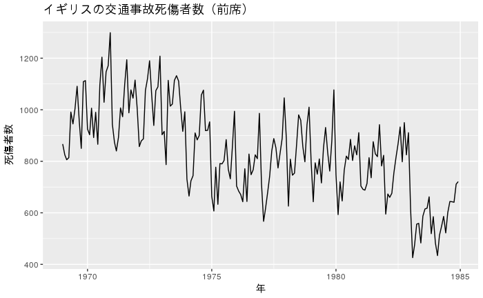

```r
ggplot2::autoplot(Seatbelts[,"front"],
                  main="イギリスの交通事故死傷者数（前席）",
                  xlab="年",
                  ylab="死傷者数")
```

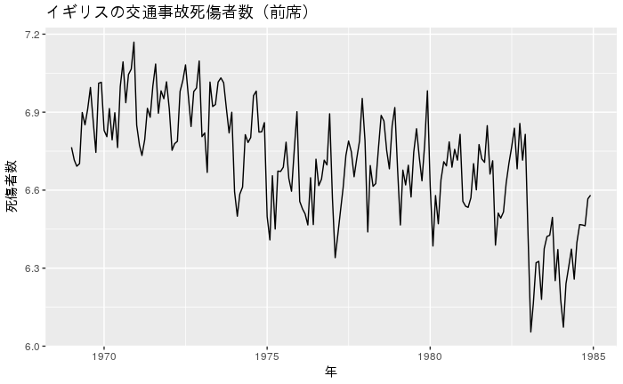

```r
ggplot2::autoplot(log(Seatbelts[,"front"]),
                  main="イギリスの交通事故死傷者数（前席）",
                  xlab="年",
                  ylab="死傷者数")
```

## 単位根検定

```r
summary(ur.kpss(log(Seatbelts[,'front'])))
```

```
#######################
# KPSS Unit Root Test #
#######################

Test is of type: mu with 4 lags.

Value of test-statistic is: 2.3004

Critical value for a significance level of:
                10pct  5pct 2.5pct  1pct
critical values 0.347 0.463  0.574 0.739
```

`ndiffs`は定常になるまでに必要な差分の回数を推定する． `alpha`で有意水準，`test`で検定の種類(kpss,adf,pp)を指定できる.

```r
ndiffs(log(Seatbelts[,'front']))
```

```
[1] 1
```

```r
forecast::ndiffs(log(Seatbelts[,'front']),test='kpss')
```

```
[1] 1
```

## ARIMA modeling

```r
library(tseries)
```

front(前席での死傷者数)をモデリングする． データとしてはさらに - PetroPrice(ガソリンの値段) - law(前席のシートベルト装着義務法律が施行されているか)

仮説： - シートベルト装着義務化(1983/1/31)で死亡者数は減った． - 交通事故は季節性がある

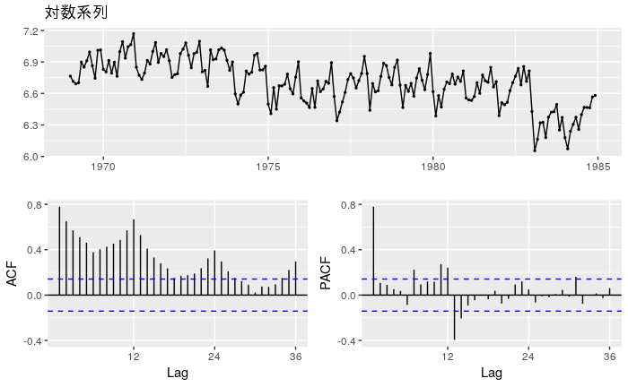

```r
log_front <- log(front)
ggtsdisplay(log_front,main='対数系列')
```

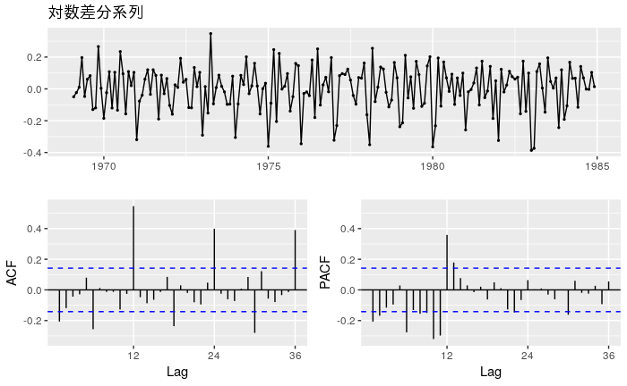

```r
log_diff <- diff(log_front,lag=1)
ggtsdisplay(log_diff,main="対数差分系列")
```

1年おきの自己相関が大きい．月ごとにグラフを書いてみる．

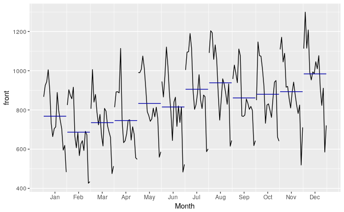

```r
ggsubseriesplot(front) #原系列
```

12月の自己数がもっとも大きいことがわかる. 季節差分をとれば，自己相関がなくなることが期待できる.

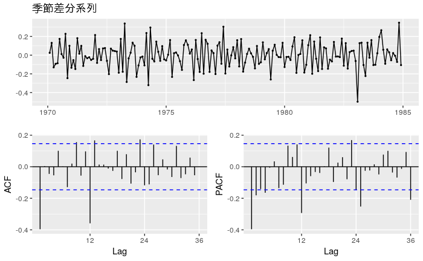

```r
seas_log_diff <- diff(log_diff,lag=frequency((log_diff)))
ggtsdisplay(seas_log_diff,main='季節差分系列')
```

まだ，12ヶ月単位の自己相関は大きい.

## 訓練データとテストデータに分ける

```r
Seatbelts_log <- Seatbelts[,c("front","PetrolPrice","law")]
Seatbelts_log[,"front"] <- log(Seatbelts_log[,"front"])
Seatbelts_log[,"PetrolPrice"] <- log(Seatbelts_log[,"PetrolPrice"])
```

```r
train <- window(Seatbelts_log,end=c(1983,12))
test <- window(Seatbelts_log,start=c(1984,1))
```

```r
petro_law <- train[,c("PetrolPrice","law")]
```

## ARIMAモデルの推定

```r
model_sarimax <- Arima(
  y = train[,"front"],
  order=c(1,1,1),
  seasonal=list(order=c(1,0,0)),
  xreg = petro_law
)
```

```r
model_sarimax
```

```
Series: train[, "front"]
Regression with ARIMA(1,1,1)(1,0,0)[12] errors

Coefficients:
         ar1      ma1    sar1  PetrolPrice      law
      0.2589  -0.9503  0.6877      -0.3464  -0.3719
s.e.  0.0826   0.0303  0.0548       0.0955   0.0467

sigma^2 estimated as 0.009052:  log likelihood=165.33
AIC=-318.66   AICc=-318.18   BIC=-299.54
```

```r
Arima(
  y=log_diff,order=c(1,0,0),
  include.mean = F
)
```

```
Series: log_diff
ARIMA(1,0,0) with zero mean

Coefficients:
          ar1
      -0.2058
s.e.   0.0706

sigma^2 estimated as 0.0202:  log likelihood=102.1
AIC=-200.21   AICc=-200.15   BIC=-193.7
```

上は以下と同じ

```r
Arima(
  y=log_front,order=c(1,1,0),include.mean = F
)
```

```
Series: log_front
ARIMA(1,1,0)

Coefficients:
          ar1
      -0.2058
s.e.   0.0706

sigma^2 estimated as 0.0202:  log likelihood=102.1
AIC=-200.21   AICc=-200.15   BIC=-193.7
```

```r
Arima(
  y=seas_log_diff,
  order=c(1,0,0),
  include.mean = F

)
```

```
Series: seas_log_diff
ARIMA(1,0,0) with zero mean

Coefficients:
          ar1
      -0.3951
s.e.   0.0685

sigma^2 estimated as 0.01569:  log likelihood=118.26
AIC=-232.52   AICc=-232.45   BIC=-226.15
```

```r
Arima(
  y=log_diff,order=c(1,0,0),
  seasonal = list(order=c(0,1,0))
)
```

```
Series: log_diff
ARIMA(1,0,0)(0,1,0)[12]

Coefficients:
          ar1
      -0.3951
s.e.   0.0685

sigma^2 estimated as 0.01569:  log likelihood=118.26
AIC=-232.52   AICc=-232.45   BIC=-226.15
```

## auto.arima

```r
sarimax_petro_law <- auto.arima(
  y=train[,"front"],
  xreg = petro_law,
  ic = "aic",
  max.order = 7,
  stepwise = F,
  approximation = F,
  parallel = T,
  num.cores = 4
)
```

```r
sarimax_petro_law
```

```
Series: train[, "front"]
Regression with ARIMA(2,0,1)(0,1,1)[12] errors

Coefficients:
         ar1      ar2      ma1     sma1  PetrolPrice      law
      1.1225  -0.1322  -0.8690  -0.8183      -0.3748  -0.3431
s.e.  0.0906   0.0876   0.0443   0.1129       0.1000   0.0473

sigma^2 estimated as 0.007624:  log likelihood=168.12
AIC=-322.23   AICc=-321.53   BIC=-300.36
```

## 定常性のチェック

```r
abs(polyroot(c(1,-coef(sarimax_petro_law)[c("ar1","ar2")])))
```

```
[1] 1.011397 7.477827
```

### MA term

```r
abs(polyroot(c(1,-coef(sarimax_petro_law)[c("ma1")])))
```

```
[1] 1.150755
```

```r
abs(polyroot(c(1,-coef(sarimax_petro_law)[c("sma1")])))
```

```
[1] 1.222057
```

check residual

```
    Ljung-Box test

data:  Residuals from Regression with ARIMA(2,0,1)(0,1,1)[12] errors
Q* = 20.99, df = 18, p-value = 0.2799

Model df: 6.   Total lags used: 24
```

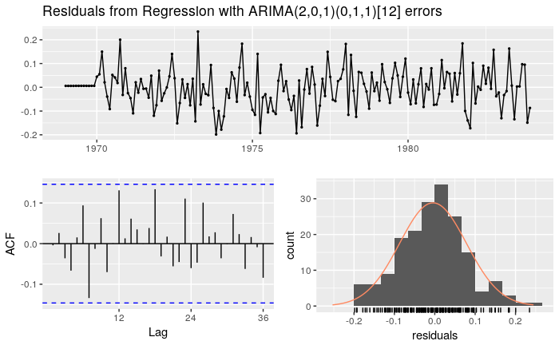

```r
checkresiduals(sarimax_petro_law)
```

Normality of residuals

help says > This test is a joint statistic using skewness and kurtosis coefficients. Missing values are not allowed.

先度と歪度でチェックしている

```r
tseries::jarque.bera.test(resid(sarimax_petro_law))
```

```
    Jarque Bera Test

data:  resid(sarimax_petro_law)
X-squared = 0.39938, df = 2, p-value = 0.819
```

## prediction

```r
petro_law_test <- test[,c("PetrolPrice","law")]
```

```r
sarimax_f <- forecast(
  sarimax_petro_law, # model
  xreg = petro_law_test, # test data
  h = 12, # predict 12 periods
  level=c(95,70), #output 95% and 70% prediction interval
)
```

```r
sarimax_f
```

```
         Point Forecast    Lo 70    Hi 70    Lo 95    Hi 95
Jan 1984       6.140922 6.050389 6.231454 5.969719 6.312124
Feb 1984       6.079469 5.986077 6.172861 5.902858 6.256080
Mar 1984       6.167368 6.072965 6.261771 5.988846 6.345890
Apr 1984       6.196306 6.101088 6.291523 6.016243 6.376368
May 1984       6.293745 6.197758 6.389732 6.112227 6.475262
Jun 1984       6.274492 6.177762 6.371222 6.091568 6.457416
Jul 1984       6.394263 6.296812 6.491714 6.209976 6.578550
Aug 1984       6.427685 6.329534 6.525836 6.242075 6.613294
Sep 1984       6.354929 6.256100 6.453759 6.168036 6.541823
Oct 1984       6.396352 6.296863 6.495840 6.208212 6.584491
Nov 1984       6.340966 6.240838 6.441095 6.151616 6.530317
Dec 1984       6.448938 6.348188 6.549689 6.258413 6.639464
```

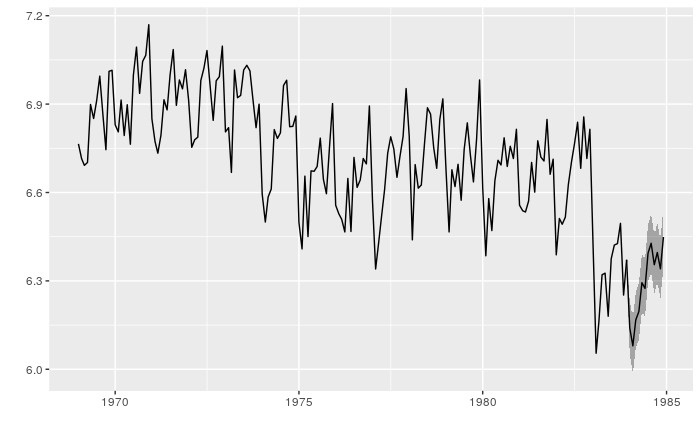

```r
autoplot(sarimax_f,predict.colour = 1)
```

```r
petro_law_mean <- data.frame(
  PetrolPrice=rep(mean(train[,"PetrolPrice"]),12),
  law=rep(1,12)
)
petro_law_mean
```

```
   PetrolPrice law
1      -2.2817   1
2      -2.2817   1
3      -2.2817   1
4      -2.2817   1
5      -2.2817   1
6      -2.2817   1
7      -2.2817   1
8      -2.2817   1
9      -2.2817   1
10     -2.2817   1
11     -2.2817   1
12     -2.2817   1
```

```r
petro_law_tail <- data.frame(
  PetrolPrice=rep(tail(train[,"PetrolPrice"],n=1),12),
  law=rep(1,12)
)
petro_law_tail
```

```
   PetrolPrice law
1     -2.13956   1
2     -2.13956   1
3     -2.13956   1
4     -2.13956   1
5     -2.13956   1
6     -2.13956   1
7     -2.13956   1
8     -2.13956   1
9     -2.13956   1
10    -2.13956   1
11    -2.13956   1
12    -2.13956   1
```

```r
sarimax_f_mean <- forecast(sarimax_petro_law,xreg=petro_law_mean)
sarimax_f_tail <- forecast(sarimax_petro_law,xreg=petro_law_tail)
```

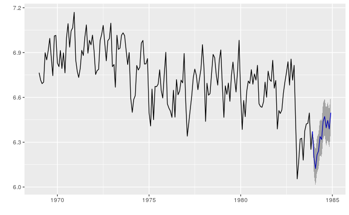

```r
autoplot(sarimax_f_mean)
```

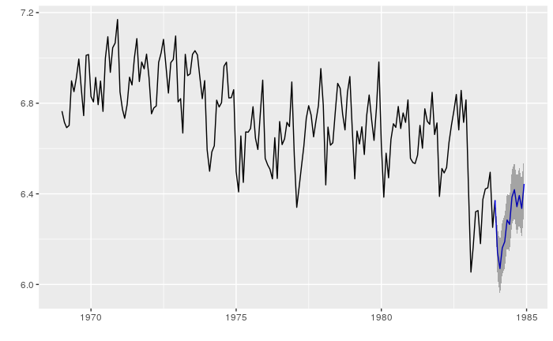

```r
autoplot(sarimax_f_tail)
```

### benchmark

```r
naive_f_mean <- forecast::meanf(train[,'front'],h=12)
naive_f_mean
```

```
         Point Forecast    Lo 80    Hi 80    Lo 95    Hi 95
Jan 1984       6.729989 6.468432 6.991546 6.328736 7.131243
Feb 1984       6.729989 6.468432 6.991546 6.328736 7.131243
Mar 1984       6.729989 6.468432 6.991546 6.328736 7.131243
Apr 1984       6.729989 6.468432 6.991546 6.328736 7.131243
May 1984       6.729989 6.468432 6.991546 6.328736 7.131243
Jun 1984       6.729989 6.468432 6.991546 6.328736 7.131243
Jul 1984       6.729989 6.468432 6.991546 6.328736 7.131243
Aug 1984       6.729989 6.468432 6.991546 6.328736 7.131243
Sep 1984       6.729989 6.468432 6.991546 6.328736 7.131243
Oct 1984       6.729989 6.468432 6.991546 6.328736 7.131243
Nov 1984       6.729989 6.468432 6.991546 6.328736 7.131243
Dec 1984       6.729989 6.468432 6.991546 6.328736 7.131243
```

```r
naive_f_latest <- forecast::rwf(train[,"front"],h=12)
naive_f_latest
```

```
         Point Forecast    Lo 80    Hi 80    Lo 95    Hi 95
Jan 1984       6.371612 6.183034 6.560190 6.083207 6.660017
Feb 1984       6.371612 6.104922 6.638301 5.963745 6.779478
Mar 1984       6.371612 6.044985 6.698239 5.872079 6.871144
Apr 1984       6.371612 5.994456 6.748768 5.794801 6.948422
May 1984       6.371612 5.949939 6.793285 5.726718 7.016506
Jun 1984       6.371612 5.909692 6.833532 5.665166 7.078057
Jul 1984       6.371612 5.872681 6.870542 5.608563 7.134660
Aug 1984       6.371612 5.838233 6.904991 5.555879 7.187345
Sep 1984       6.371612 5.805878 6.937346 5.506396 7.236828
Oct 1984       6.371612 5.775276 6.967948 5.459594 7.283629
Nov 1984       6.371612 5.746169 6.997054 5.415080 7.328144
Dec 1984       6.371612 5.718358 7.024865 5.372547 7.370677
```

## evaluation

```r
forecast::accuracy(sarimax_f,x=test[,"front"])
```

```
                       ME       RMSE        MAE         MPE      MAPE      MASE       ACF1 Theil's U
Training set -0.004353509 0.08283297 0.06430968 -0.07784816 0.9593004 0.5848660 -0.0040321        NA
Test set      0.071495376 0.09674572 0.07537019  1.10793155 1.1703728 0.6854562  0.3376395   1.03686
```

```r
forecast::accuracy(sarimax_f_mean,x=test[,"front"])
```

```
                       ME       RMSE        MAE         MPE      MAPE      MASE       ACF1 Theil's U
Training set -0.004353509 0.08283297 0.06430968 -0.07784816 0.9593004 0.5848660 -0.0040321        NA
Test set      0.025426857 0.06945114 0.05363524  0.38363229 0.8362867 0.4877871  0.3205392 0.7478235
```

```r
forecast::accuracy(sarimax_f_tail,x=test[,"front"])
```

```
                       ME       RMSE        MAE         MPE      MAPE     MASE       ACF1 Theil's U
Training set -0.004353509 0.08283297 0.06430968 -0.07784816 0.9593004 0.584866 -0.0040321        NA
Test set      0.078697629 0.10183444 0.07992764  1.22110442 1.2407604 0.726904  0.3205392  1.092863
```